# UNIVERSIDADE FEDERAL DE LAVRAS Geomática para Ambientes Tarefa 03

Vítor Ferreira

16/12/2023

## Objetivo

O objetivo é obter dados de levantamento GNSS de lavoura cafeeira e monitoramento da segunda florada com drone e câmera RGB.

## Manipulação de dados vetoriais

Para a manipulação dos dodos foi utilizado o pacote “terra”. Uma classe define um tipo de dados específico.Para dados vetoriais, a classe utilizada é SpatVector. Essas classes representam geometrias, bem como atributos (variáveis) que descrevem as geometrias.

## Pacotes Utilizados

```r
library(terra)
library(viridis)
```

## Dados Espaciais Medidos em Campo

Os dados foram recolhidos no momento do voo, utilizando um GPS/GNSS com base RTK e Rover. Obtendo as seguintes longituides e latitudes que foram inseridas no R. Para unir as latitudes e longitudes, aqui chamadas de “lat” e “lon”. Utiliza-se a função cbind.

```r
lat <- c(7652767.619,7652755.703,7652742.460,7652765.809,7652803.896,7652822.483,
7652833.112,7652791.364,7652774.442,7652792.841)
lon <- c(502994.648,503008.785,503022.257,503046.640,503086.868,503074.261,
503063.465,503038.045,503035.942,503019.689)
lonlat <- cbind(lon, lat)
```

Na sequeência os dados foram convertidos em SpatVector com a função vect.

```r
pts <- vect(lonlat)
pts
```

```
##  class       : SpatVector
##  geometry    : points
##  dimensions  : 10, 0  (geometries, attributes)
##  extent      : 502994.6, 503086.9, 7652742, 7652833  (xmin, xmax, ymin, ymax)
##  coord. ref. :
```

A função geom é utilizada para observar os dados contidos no objeto recém criado acima nomeado como “pts”.

```r
geom(pts)
```

```
##       geom part        x       y hole
##  [1,]    1    1 502994.6 7652768    0
##  [2,]    2    1 503008.8 7652756    0
##  [3,]    3    1 503022.3 7652742    0
##  [4,]    4    1 503046.6 7652766    0
##  [5,]    5    1 503086.9 7652804    0
##  [6,]    6    1 503074.3 7652822    0
##  [7,]    7    1 503063.5 7652833    0
##  [8,]    8    1 503038.0 7652791    0
##  [9,]    9    1 503035.9 7652774    0
## [10,]   10    1 503019.7 7652793    0
```

Os dados de levantamento foram obtidos no sistema de referência de coordenadas WGS 84 / UTM zone 23S (EPSG:32723). Utilizando o argumento crs, dentro da função vect. Podemos atribuir o sistema de coordenadas aos dados.

```r
pts <- vect(lonlat, crs = "EPSG:32723")
pts
```

```
##  class       : SpatVector
##  geometry    : points
##  dimensions  : 10, 0  (geometries, attributes)
##  extent      : 502994.6, 503086.9, 7652742, 7652833  (xmin, xmax, ymin, ymax)
##  coord. ref. : WGS 84 / UTM zone 23S (EPSG:32723)
```

A função crs permite obter mais detalhes sobre o sistema de coordenadas. Foi utilizado então o objeto pts, a partir da função crs

```r
crs(pts)
```

```
## [1] "PROJCRS[\"WGS 84 / UTM zone 23S\",\n    BASEGEOGCRS[\"WGS 84\",\n        DATUM[\"World Geodetic System 1984\",\n            ELLIPSOID[\"WGS 84\",6378137,298.257223563,\n                LENGTHUNIT[\"metre\",1]]],\n        PRIMEM[\"Greenwich\",0,\n            ANGLEUNIT[\"degree\",0.01745329251…
```

Foram adicionados também os dados de altitude recolhidos a partir do GPS. A altitude e um número identificador de cada ponto foram adicionados aos dados a partir de um data.frame. Sendo os dados de altitudes chamados de “alt” e o novo data frame criado chamado de “df”.

```r
alt <- c(937.908,939.623,940.965,941.401,941.425,939.685,938.216,939.365,940.390,
938.220)
df <- data.frame(ID = 1:nrow(lonlat), altitude = alt)
```

E então o resultado do objeto “df”

```r
df
```

```
##    ID altitude
## 1   1  937.908
## 2   2  939.623
## 3   3  940.965
## 4   4  941.401
## 5   5  941.425
## 6   6  939.685
## 7   7  938.216
## 8   8  939.365
## 9   9  940.390
## 10 10  938.220
```

O data.frame criado foi combinado com o objeto SpatVector de pontos espaciais.

```r
pt <- vect(lonlat, atts = df, crs = "EPSG:32723")
```

## Plotando as Imagem com os pontos de controle

Para plotar os pontos de controle com referência na imagem, foi utilizado o arquivo RGB .tif da segunda florada. Utilizando a função “rast” do pacote terra e especificando corretamente o endereço da imagem armazenado no servidor.

```r
rgb_florada_2<- rast("/home/vitor/Disciplinas_especiais_UFLA/geomatica/imagem_drone/Campus-Ufla-06-10-2023-all/odm_orthophoto/odm_orthophoto.tif")
```

Após a leitura da imagem .tif, verificar as propriedadades da imagem utilizando digitando o nome dado ao objeto criado “rgb_florada_2”

```r
rgb_florada_2
```

```
## class       : SpatRaster
## dimensions  : 4346, 4261, 4  (nrow, ncol, nlyr)
## resolution  : 0.05, 0.04999549  (x, y)
## extent      : 502937.4, 503150.5, 7652679, 7652896  (xmin, xmax, ymin, ymax)
## coord. ref. : WGS 84 / UTM zone 23S (EPSG:32723)
## source      : odm_orthophoto.tif
## names       : red, green, blue, odm_orthophoto_4
```

Essas informações são importantes já que mostram o sistema de coordenadas utilizado e as colunas, que vão representar as bandas espectrais red, green e blue. Para então fazer uma composição dessas camadas. Abaixo o plot apenas com os pontos de controle.

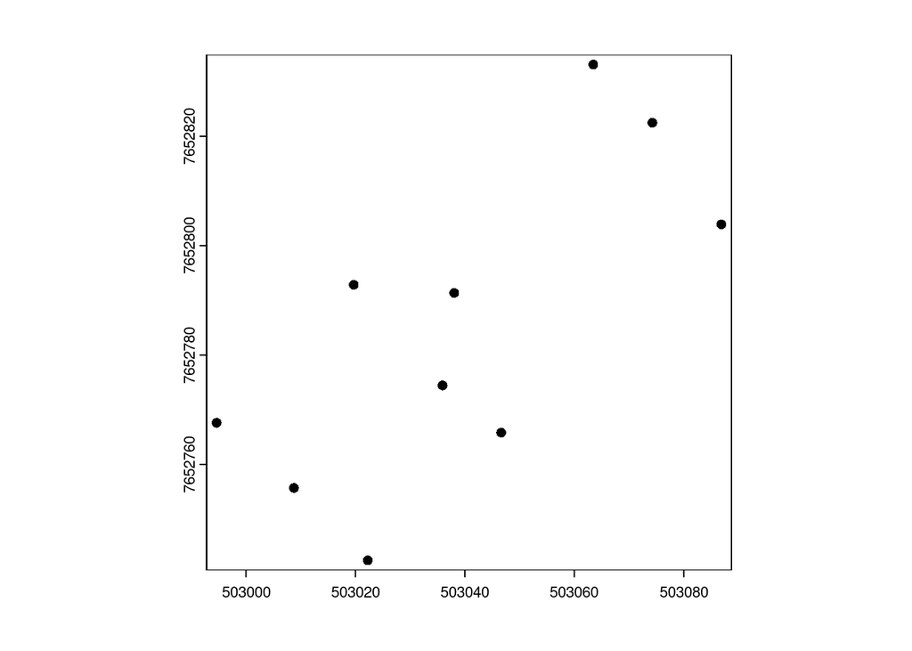

```r
plot(pt)
```

E na sequencia a referência da imagem .tif com os pontos de controle, ortoretificados.

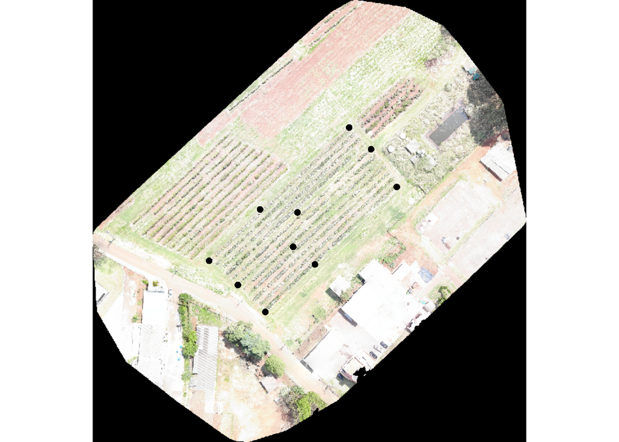

```r
plotRGB(rgb_florada_2, r= 1, g= 2, b=3)
plot(pt, add=T)
```

## Modelo Digital de Elevação da Superfície

Primeiramente importando as imagens ortoretificadas, de acordo com o endereço dos arquivos no servidor.

```r
modelo_elev_2_florada <- rast("/home/vitor/Disciplinas_especiais_UFLA/geomatica/imagem_drone/Campus-Ufla-06-10-2023-all/odm_dem/dsm.tif")
```

A função “plot” foi utilizada para mapear o modelo digital de elevação.

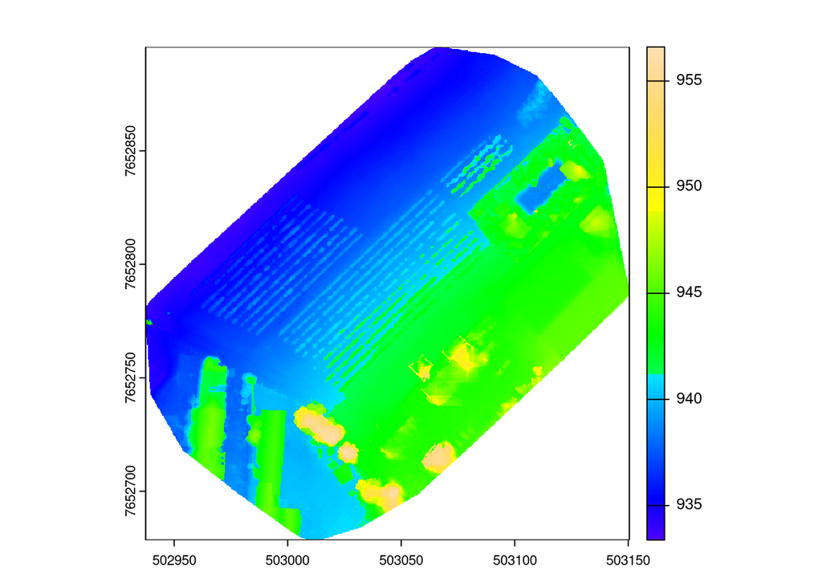

```r
plot(modelo_elev_2_florada, col = topo.colors(256))
```

Observa-se alguns poucos pontos acima de 950 metros

## Referência

Robert J. Hijmans (2023). terra: Spatial Data Analysis. R package version 1.7-62. https://rspatial.org/

Simon Garnier, Noam Ross, Robert Rudis, Antônio P. Camargo, Marco Sciaini, and Cédric Scherer (2023). viridis(Lite) - Colorblind-Friendly Color Maps for R. viridis package version 0.6.4.